# SpaceX Falcon 9 First Stage Landing Analysis

## Exploring and Preparing Data

Estimated time: About 70 minutes (may vary depending on your pace)

In this notebook, I will explore and prepare the Falcon 9 launch data to better understand the factors that influence landing success. The ability to reuse the first stage is a key reason for SpaceX's cost advantage, and predicting landing outcomes is both a technical and business challenge.

I will perform exploratory data analysis (EDA) and feature engineering to prepare the data for future modeling.

### What makes a Falcon 9 landing successful?

[figure not shown]

Below, I will also highlight some examples of unsuccessful landings, which are important for understanding the challenges SpaceX faces.

[figure not shown]

Note: Some unsuccessful landings are planned, such as controlled descents into the ocean.

## My Objectives

- Perform exploratory data analysis (EDA)
- Engineer features for modeling
- Visualize key patterns and relationships in the data

### Import Libraries and Define Helper Functions

I will import the following libraries for data analysis and visualization.

```python
# import piplite
# await piplite.install(['numpy'])
# await piplite.install(['pandas'])
# await piplite.install(['seaborn'])
```

```python
# pandas is a software library written for the Python programming language for data manipulation and analysis.
import pandas as pd
#NumPy is a library for the Python programming language, adding support for large, multi-dimensional arrays and matrices, along with a large collection of high-level mathematical functions to operate on these arrays
import numpy as np
# Matplotlib is a plotting library for python and pyplot gives us a MatLab like plotting framework. We will use this in our plotter function to plot data.
import matplotlib.pyplot as plt
#Seaborn is a Python data visualization library based on matplotlib. It provides a high-level interface for drawing attractive and informative statistical graphics
import seaborn as sns
```

## Exploratory Data Analysis

First, let's read the SpaceX dataset into a Pandas dataframe and print its summary

```python
!pip install js
```

```
  Preparing metadata (setup.py) ... done
     ━━━━━━━━━━━━━━━━━━━━━━━━━━━━━━━━━━━━━━━━ 53.9/53.9 kB 700.9 kB/s eta 0:00:00
     ━━━━━━━━━━━━━━━━━━━━━━━━━━━━━━━━━━━━━━━━ 115.0/115.0 kB 2.8 MB/s eta 0:00:00
```

```python
from google.colab import drive
drive.mount('/content/drive')
```

```python
sns.set(rc={'figure.figsize':(14, 6)})
URL = "/content/drive/MyDrive/IBM Data Science Capstone/dataset_part_2.csv"

df=pd.read_csv(URL)
df.head(5)
```

|  | FlightNumber | Date | BoosterVersion | PayloadMass | Orbit | LaunchSite | Outcome | Flights | GridFins | Reused | Legs | LandingPad | Block | ReusedCount | Serial | Longitude | Latitude | Class |
| --- | --- | --- | --- | --- | --- | --- | --- | --- | --- | --- | --- | --- | --- | --- | --- | --- | --- | --- |
| 0 | 1 | 2010-06-04 | Falcon 9 | 6104.959412 | LEO | CCAFS SLC 40 | None None | 1 | False | False | False | NaN | 1.0 | 0 | B0003 | -80.577366 | 28.561857 | 0 |
| 1 | 2 | 2012-05-22 | Falcon 9 | 525.000000 | LEO | CCAFS SLC 40 | None None | 1 | False | False | False | NaN | 1.0 | 0 | B0005 | -80.577366 | 28.561857 | 0 |
| 2 | 3 | 2013-03-01 | Falcon 9 | 677.000000 | ISS | CCAFS SLC 40 | None None | 1 | False | False | False | NaN | 1.0 | 0 | B0007 | -80.577366 | 28.561857 | 0 |
| 3 | 4 | 2013-09-29 | Falcon 9 | 500.000000 | PO | VAFB SLC 4E | False Ocean | 1 | False | False | False | NaN | 1.0 | 0 | B1003 | -120.610829 | 34.632093 | 0 |
| 4 | 5 | 2013-12-03 | Falcon 9 | 3170.000000 | GTO | CCAFS SLC 40 | None None | 1 | False | False | False | NaN | 1.0 | 0 | B1004 | -80.577366 | 28.561857 | 0 |

First, let's try to see how the `FlightNumber` (indicating the continuous launch attempts.) and `Payload` variables would affect the launch outcome.

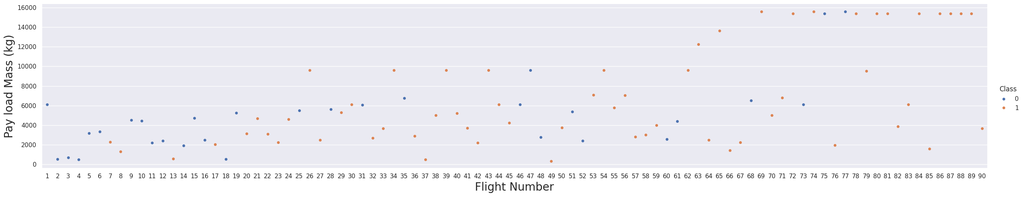

```python
sns.catplot(y="PayloadMass", x="FlightNumber", hue="Class", data=df, aspect = 5)
plt.xlabel("Flight Number",fontsize=20)
plt.ylabel("Pay load Mass (kg)",fontsize=20)
plt.show()
```

We see that different launch sites have different success rates. `CCAFS LC-40`, has a success rate of 60 %, while `KSC LC-39A` and `VAFB SLC 4E` has a success rate of 77%.

Next, let's drill down to each site visualize its detailed launch records.

### TASK 1: Visualize the relationship between Flight Number and Launch Site

Use the function `catplot` to plot `FlightNumber` vs `LaunchSite`, set the parameter `x` parameter to `FlightNumber`,set the `y` to `Launch Site` and set the parameter `hue` to `'class'`

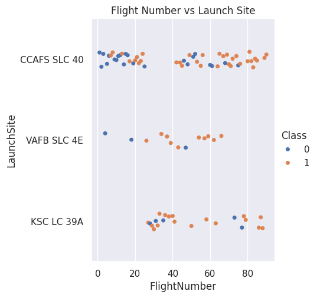

```python
# Use catplot to plot FlightNumber vs LaunchSite
sns.catplot(x='FlightNumber', y='LaunchSite', hue='Class', data=df,aspect=1)

# Set the title of the plot
plt.title('Flight Number vs Launch Site')

# Show the plot
plt.show()
```

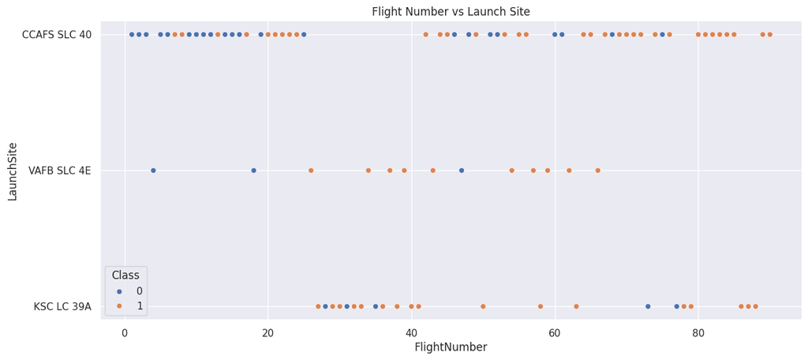

```python
# Plot a scatter point chart with x axis to be Flight Number and y axis to be the launch site, and hue to be the class value

# Plot scatter point chart
sns.scatterplot(x='FlightNumber', y='LaunchSite', hue='Class', data=df)

# Set the title of the plot
plt.title('Flight Number vs Launch Site')

# Show the plot
plt.show()
```

Now try to explain the patterns you found in the Flight Number vs. Launch Site scatter point plots.

### TASK 2: Visualize the relationship between Payload and Launch Site

We also want to observe if there is any relationship between launch sites and their payload mass.

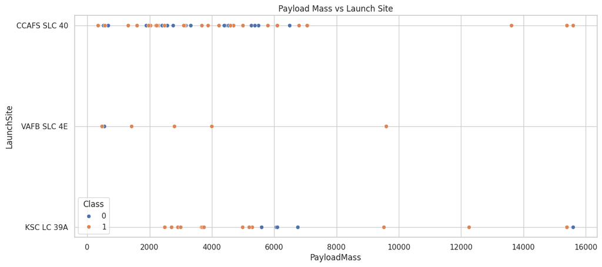

```python
# Plot a scatter point chart with x axis to be Pay Load Mass (kg) and y axis to be the launch site, and hue to be the class value

# Set the style of the visualization
sns.set_style("whitegrid")

# Create a scatter plot
sns.scatterplot(x='PayloadMass', y='LaunchSite', hue='Class', data=df)

# Set the title of the plot
plt.title('Payload Mass vs Launch Site')

# Show the plot
plt.show()
```

```python
# Display the DataFrame
print(df[['PayloadMass', 'LaunchSite', 'Class']].to_string(index=False))
```

```
 PayloadMass   LaunchSite  Class
 6104.959412 CCAFS SLC 40      0
  525.000000 CCAFS SLC 40      0
  677.000000 CCAFS SLC 40      0
  500.000000  VAFB SLC 4E      0
 3170.000000 CCAFS SLC 40      0
 3325.000000 CCAFS SLC 40      0
 2296.000000 CCAFS SLC 40      1
 1316.000000 CCAFS SLC 40      1
 4535.000000 CCAFS SLC 40      0
 4428.000000 CCAFS SLC 40      0
 2216.000000 CCAFS SLC 40      0
 2395.000000 CCAFS SLC 40      0
  570.000000 CCAFS SLC 40      1
 1898.000000 CCAFS SLC 40      0
 4707.000000 CCAFS SLC 40      0
 2477.000000 CCAFS SLC 40      0
 2034.000000 CCAFS SLC 40      1
  553.000000  VAFB SLC 4E      0
 5271.000000 CCAFS SLC 40      0
 3136.000000 CCAFS SLC 40      1
 4696.000000 CCAFS SLC 40      1
 3100.000000 CCAFS SLC 40      1
 2257.000000 CCAFS SLC 40      1
 4600.000000 CCAFS SLC 40      1
 5500.000000 CCAFS SLC 40      0
 9600.000000  VAFB SLC 4E      1
 2490.000000   KSC LC 39A      1
 5600.000000   KSC LC 39A      0
 5300.000000   KSC LC 39A      1
 6104.959412   KSC LC 39A      1
 6070.000000   KSC LC 39A      0
 2708.000000   KSC LC 39A      1
 3669.000000   KSC LC 39A      1
 9600.000000  VAFB SLC 4E      1
 6761.000000   KSC LC 39A      0
 2910.000000   KSC LC 39A      1
  475.000000  VAFB SLC 4E      1
 4990.000000   KSC LC 39A      1
 9600.000000  VAFB SLC 4E      1
```

[output cut: 36 more lines]

```
 1977.000000 CCAFS SLC 40      1
15600.000000   KSC LC 39A      0
15400.000000   KSC LC 39A      1
 9525.000000   KSC LC 39A      1
15400.000000 CCAFS SLC 40      1
15400.000000 CCAFS SLC 40      1
 3880.000000 CCAFS SLC 40      1
 6104.959412 CCAFS SLC 40      1
15400.000000 CCAFS SLC 40      1
 1600.000000 CCAFS SLC 40      1
15400.000000   KSC LC 39A      1
15400.000000   KSC LC 39A      1
15400.000000   KSC LC 39A      1
15400.000000 CCAFS SLC 40      1
 3681.000000 CCAFS SLC 40      1
```

Now if you observe Payload Vs. Launch Site scatter point chart you will find for the VAFB-SLC launchsite there are no rockets launched for heavypayload mass(greater than 10000).

### TASK 3: Visualize the relationship between success rate of each orbit type

Next, we want to visually check if there are any relationship between success rate and orbit type.

Let's create a `bar chart` for the sucess rate of each orbit

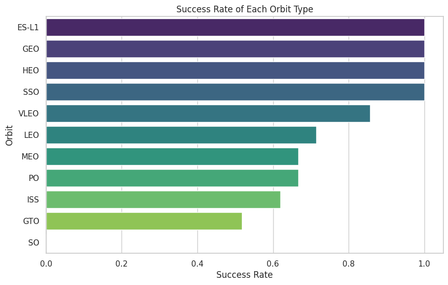

```python
# HINT use groupby method on Orbit column and get the mean of Class column
# Calculate the success rate for each orbit type
orbit_success_rate = df.groupby('Orbit')['Class'].mean().reset_index()

# Sort the dataframe by success rate in descending order
orbit_success_rate = orbit_success_rate.sort_values(by='Class', ascending=False)

# Create a bar plot
plt.figure(figsize=(10, 6))
sns.barplot(x='Class', y='Orbit', data=orbit_success_rate, palette='viridis')

# Set the title and labels
plt.title('Success Rate of Each Orbit Type')
plt.xlabel('Success Rate')
plt.ylabel('Orbit')

# Show the plot
plt.show()
```

```python
orbit_success_rate
```

|  | Orbit | Class |
| --- | --- | --- |
| 0 | ES-L1 | 1.000000 |
| 1 | GEO | 1.000000 |
| 3 | HEO | 1.000000 |
| 9 | SSO | 1.000000 |
| 10 | VLEO | 0.857143 |
| 5 | LEO | 0.714286 |
| 6 | MEO | 0.666667 |
| 7 | PO | 0.666667 |
| 4 | ISS | 0.619048 |
| 2 | GTO | 0.518519 |
| 8 | SO | 0.000000 |

Analyze the ploted bar chart try to find which orbits have high sucess rate.

### TASK 4: Visualize the relationship between FlightNumber and Orbit type

For each orbit, we want to see if there is any relationship between FlightNumber and Orbit type.

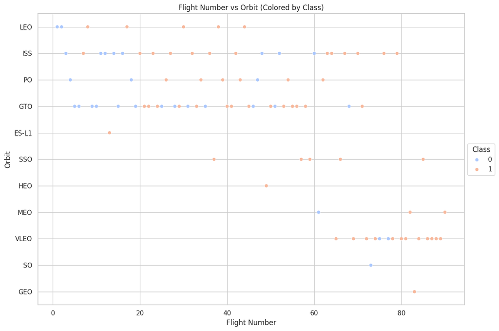

```python
# Plot a scatter point chart with x axis to be FlightNumber and y axis to be the Orbit, and hue to be the class value
# Create the scatter plot
plt.figure(figsize=(12, 8))
sns.scatterplot(data=df, x='FlightNumber', y='Orbit', hue='Class', palette='coolwarm')

# Set the title and labels
plt.title('Flight Number vs Orbit (Colored by Class)')
plt.xlabel('Flight Number')
plt.ylabel('Orbit')

# Show the plot
plt.legend(title='Class', loc='center left', bbox_to_anchor=(1, 0.5))
plt.grid(True)
plt.tight_layout()
plt.show()
```

```python
# Display the DataFrame
print(df[['FlightNumber', 'Orbit', 'Class']].to_string(index=False))
```

```
 FlightNumber Orbit  Class
            1   LEO      0
            2   LEO      0
            3   ISS      0
            4    PO      0
            5   GTO      0
            6   GTO      0
            7   ISS      1
            8   LEO      1
            9   GTO      0
           10   GTO      0
           11   ISS      0
           12   ISS      0
           13 ES-L1      1
           14   ISS      0
```

[output cut: 76 more lines]

You should see that in the LEO orbit the Success appears related to the number of flights; on the other hand, there seems to be no relationship between flight number when in GTO orbit.

### TASK 5: Visualize the relationship between Payload and Orbit type

Similarly, we can plot the Payload vs. Orbit scatter point charts to reveal the relationship between Payload and Orbit type

```python
# Display the DataFrame
print(df[['PayloadMass', 'Orbit', 'Class']].to_string(index=False))
```

```
 PayloadMass Orbit  Class
 6104.959412   LEO      0
  525.000000   LEO      0
  677.000000   ISS      0
  500.000000    PO      0
 3170.000000   GTO      0
 3325.000000   GTO      0
 2296.000000   ISS      1
 1316.000000   LEO      1
 4535.000000   GTO      0
 4428.000000   GTO      0
 2216.000000   ISS      0
 2395.000000   ISS      0
  570.000000 ES-L1      1
 1898.000000   ISS      0
 4707.000000   GTO      0
 2477.000000   ISS      0
 2034.000000   LEO      1
  553.000000    PO      0
 5271.000000   GTO      0
 3136.000000   ISS      1
 4696.000000   GTO      1
 3100.000000   GTO      1
 2257.000000   ISS      1
 4600.000000   GTO      1
 5500.000000   GTO      0
 9600.000000    PO      1
 2490.000000   ISS      1
 5600.000000   GTO      0
 5300.000000   GTO      1
 6104.959412   LEO      1
 6070.000000   GTO      0
 2708.000000   ISS      1
 3669.000000   GTO      1
 9600.000000    PO      1
 6761.000000   GTO      0
 2910.000000   ISS      1
  475.000000   SSO      1
 4990.000000   LEO      1
 9600.000000    PO      1
```

[output cut: 36 more lines]

```
 1977.000000   ISS      1
15600.000000  VLEO      0
15400.000000  VLEO      1
 9525.000000   ISS      1
15400.000000  VLEO      1
15400.000000  VLEO      1
 3880.000000   MEO      1
 6104.959412   GEO      1
15400.000000  VLEO      1
 1600.000000   SSO      1
15400.000000  VLEO      1
15400.000000  VLEO      1
15400.000000  VLEO      1
15400.000000  VLEO      1
 3681.000000   MEO      1
```

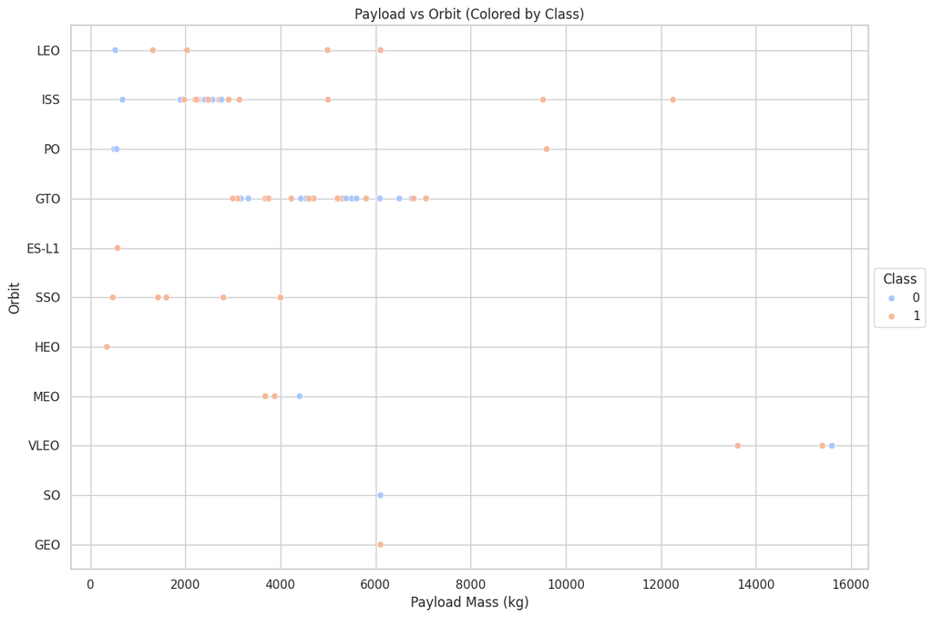

```python
# Plot a scatter point chart with x axis to be Payload and y axis to be the Orbit, and hue to be the class value
# Create the scatter plot
plt.figure(figsize=(12, 8))
sns.scatterplot(data=df, x='PayloadMass', y='Orbit', hue='Class', palette='coolwarm')

# Set the title and labels
plt.title('Payload vs Orbit (Colored by Class)')
plt.xlabel('Payload Mass (kg)')
plt.ylabel('Orbit')

# Show the plot
plt.legend(title='Class', loc='center left', bbox_to_anchor=(1, 0.5))
plt.grid(True)
plt.tight_layout()
plt.show()
```

With heavy payloads the successful landing or positive landing rate are more for Polar,LEO and ISS.

However for GTO we cannot distinguish this well as both positive landing rate and negative landing(unsuccessful mission) are both there here.

### TASK 6: Visualize the launch success yearly trend

You can plot a line chart with x axis to be `Year` and y axis to be average success rate, to get the average launch success trend.

The function will help you get the year from the date:

```python
# A function to Extract years from the date
year=[]
def Extract_year():
    for i in df["Date"]:
        year.append(i.split("-")[0])
    return year
Extract_year()
df['Date'] = year
df.head()
```

|  | FlightNumber | Date | BoosterVersion | PayloadMass | Orbit | LaunchSite | Outcome | Flights | GridFins | Reused | Legs | LandingPad | Block | ReusedCount | Serial | Longitude | Latitude | Class |
| --- | --- | --- | --- | --- | --- | --- | --- | --- | --- | --- | --- | --- | --- | --- | --- | --- | --- | --- |
| 0 | 1 | 2010 | Falcon 9 | 6104.959412 | LEO | CCAFS SLC 40 | None None | 1 | False | False | False | NaN | 1.0 | 0 | B0003 | -80.577366 | 28.561857 | 0 |
| 1 | 2 | 2012 | Falcon 9 | 525.000000 | LEO | CCAFS SLC 40 | None None | 1 | False | False | False | NaN | 1.0 | 0 | B0005 | -80.577366 | 28.561857 | 0 |
| 2 | 3 | 2013 | Falcon 9 | 677.000000 | ISS | CCAFS SLC 40 | None None | 1 | False | False | False | NaN | 1.0 | 0 | B0007 | -80.577366 | 28.561857 | 0 |
| 3 | 4 | 2013 | Falcon 9 | 500.000000 | PO | VAFB SLC 4E | False Ocean | 1 | False | False | False | NaN | 1.0 | 0 | B1003 | -120.610829 | 34.632093 | 0 |
| 4 | 5 | 2013 | Falcon 9 | 3170.000000 | GTO | CCAFS SLC 40 | None None | 1 | False | False | False | NaN | 1.0 | 0 | B1004 | -80.577366 | 28.561857 | 0 |

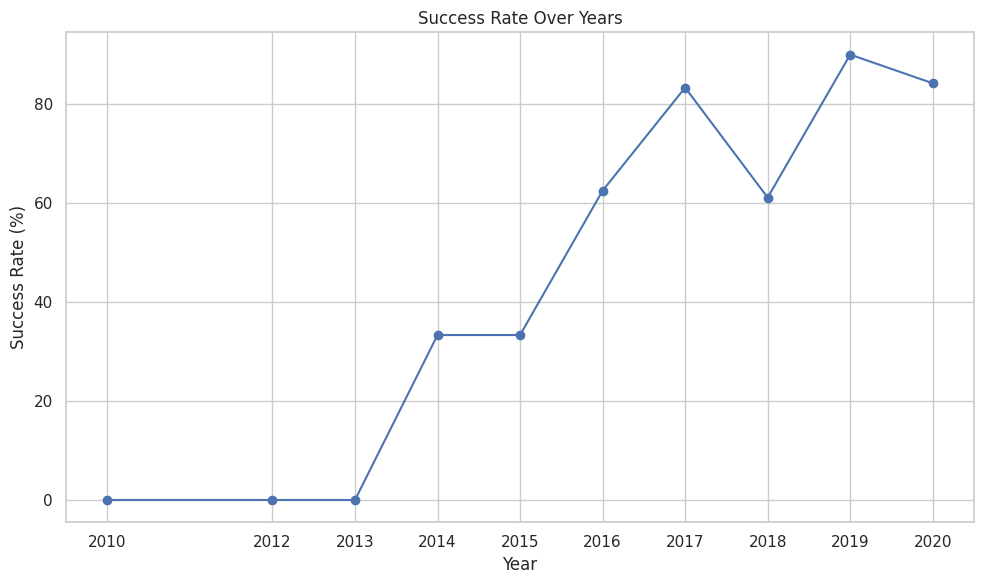

```python
# Plot a line chart with x axis to be the extracted year and y axis to be the success rate
# Ensure 'Date' column is in datetime format
df['Date'] = pd.to_datetime(df['Date'])

# Extract year from the 'Date' column
df['Date'] = df['Date'].dt.year
# Calculate success rate for each year
success_rate = df.groupby('Date')['Class'].apply(lambda x: (x == 1).mean() * 100)

# Plot line chart
plt.figure(figsize=(10, 6))
success_rate.plot(marker='o', color='b', linestyle='-')

# Set the title and labels
plt.title('Success Rate Over Years')
plt.xlabel('Year')
plt.ylabel('Success Rate (%)')

# Set ticks for x-axis
plt.xticks(success_rate.index)

# Show the plot
plt.grid(True)
plt.tight_layout()
plt.show()
```

```python
success_rate
```

```
Date
2010     0.000000
2012     0.000000
2013     0.000000
2014    33.333333
2015    33.333333
2016    62.500000
2017    83.333333
2018    61.111111
2019    90.000000
2020    84.210526
Name: Class, dtype: float64
```

## Features Engineering

By now, you should obtain some preliminary insights about how each important variable would affect the success rate, we will select the features that will be used in success prediction in the future module.

```python
features = df[['FlightNumber', 'PayloadMass', 'Orbit', 'LaunchSite', 'Flights', 'GridFins', 'Reused', 'Legs', 'LandingPad', 'Block', 'ReusedCount', 'Serial']]
features.head()
```

|  | FlightNumber | PayloadMass | Orbit | LaunchSite | Flights | GridFins | Reused | Legs | LandingPad | Block | ReusedCount | Serial |
| --- | --- | --- | --- | --- | --- | --- | --- | --- | --- | --- | --- | --- |
| 0 | 1 | 6104.959412 | LEO | CCAFS SLC 40 | 1 | False | False | False | NaN | 1.0 | 0 | B0003 |
| 1 | 2 | 525.000000 | LEO | CCAFS SLC 40 | 1 | False | False | False | NaN | 1.0 | 0 | B0005 |
| 2 | 3 | 677.000000 | ISS | CCAFS SLC 40 | 1 | False | False | False | NaN | 1.0 | 0 | B0007 |
| 3 | 4 | 500.000000 | PO | VAFB SLC 4E | 1 | False | False | False | NaN | 1.0 | 0 | B1003 |
| 4 | 5 | 3170.000000 | GTO | CCAFS SLC 40 | 1 | False | False | False | NaN | 1.0 | 0 | B1004 |

### TASK 7: Create dummy variables to categorical columns

Use the function `get_dummies` and `features` dataframe to apply OneHotEncoder to the column `Orbits`, `LaunchSite`, `LandingPad`, and `Serial`. Assign the value to the variable `features_one_hot`, display the results using the method head. Your result dataframe must include all features including the encoded ones.

```python
# HINT: Use get_dummies() function on the categorical columns
# Columns to apply one-hot encoding
columns_to_encode = ['Orbit', 'LaunchSite', 'LandingPad', 'Serial']

# Apply one-hot encoding
features_one_hot = pd.get_dummies(features, columns=columns_to_encode)

# Display the results
print(features_one_hot.head())
```

```
   FlightNumber  PayloadMass  Flights  GridFins  Reused   Legs  Block  \
0             1  6104.959412        1     False   False  False    1.0
1             2   525.000000        1     False   False  False    1.0
2             3   677.000000        1     False   False  False    1.0
3             4   500.000000        1     False   False  False    1.0
4             5  3170.000000        1     False   False  False    1.0

   ReusedCount  Orbit_ES-L1  Orbit_GEO  ...  Serial_B1048  Serial_B1049  \
0            0            0          0  ...             0             0
1            0            0          0  ...             0             0
2            0            0          0  ...             0             0
3            0            0          0  ...             0             0
4            0            0          0  ...             0             0

   Serial_B1050  Serial_B1051  Serial_B1054  Serial_B1056  Serial_B1058  \
0             0             0             0             0             0
1             0             0             0             0             0
2             0             0             0             0             0
3             0             0             0             0             0
4             0             0             0             0             0

   Serial_B1059  Serial_B1060  Serial_B1062
0             0             0             0
1             0             0             0
2             0             0             0
3             0             0             0
4             0             0             0

[5 rows x 80 columns]
```

### TASK 8: Cast all numeric columns to `float64`

Now that our `features_one_hot` dataframe only contains numbers cast the entire dataframe to variable type `float64`

```python
# HINT: use astype function
# Cast the entire DataFrame to float64
features_one_hot = features_one_hot.astype('float64')

# Display the results
print(features_one_hot.head())
```

```
   FlightNumber  PayloadMass  Flights  GridFins  Reused  Legs  Block  \
0           1.0  6104.959412      1.0       0.0     0.0   0.0    1.0
1           2.0   525.000000      1.0       0.0     0.0   0.0    1.0
2           3.0   677.000000      1.0       0.0     0.0   0.0    1.0
3           4.0   500.000000      1.0       0.0     0.0   0.0    1.0
4           5.0  3170.000000      1.0       0.0     0.0   0.0    1.0

   ReusedCount  Orbit_ES-L1  Orbit_GEO  ...  Serial_B1048  Serial_B1049  \
0          0.0          0.0        0.0  ...           0.0           0.0
1          0.0          0.0        0.0  ...           0.0           0.0
2          0.0          0.0        0.0  ...           0.0           0.0
3          0.0          0.0        0.0  ...           0.0           0.0
4          0.0          0.0        0.0  ...           0.0           0.0

   Serial_B1050  Serial_B1051  Serial_B1054  Serial_B1056  Serial_B1058  \
0           0.0           0.0           0.0           0.0           0.0
1           0.0           0.0           0.0           0.0           0.0
2           0.0           0.0           0.0           0.0           0.0
3           0.0           0.0           0.0           0.0           0.0
4           0.0           0.0           0.0           0.0           0.0

   Serial_B1059  Serial_B1060  Serial_B1062
0           0.0           0.0           0.0
1           0.0           0.0           0.0
2           0.0           0.0           0.0
3           0.0           0.0           0.0
4           0.0           0.0           0.0

[5 rows x 80 columns]
```

We can now export it to a **CSV** for the next section,but to make the answers consistent, in the next lab we will provide data in a pre-selected date range.

```python
features_one_hot.to_csv('dataset_part_3.csv', index=False)
```

`features_one_hot.to_csv('dataset_part_3.csv', index=False)`

## Authors

Pratiksha Verma

## Change Log

| Date (YYYY-MM-DD) | Version | Changed By | Change Description |
| --- | --- | --- | --- |
| 2022-11-09 | 1.0 | Pratiksha Verma | Converted initial version to Jupyterlite |